# Assignment 2 - Differential Gene expression and Preliminary ORA

YUhan Hu

# Introduction

GEO data used is GSE114260.Refer to corresponding paper, **combined** in file name means this file contains samples from both human and mice, since we only care about human, don’t need to use the two **combined** file. Therefore, the **stranded_read_counts** is the data file of interest.

To clarify, **ER** in this data set stands for **estrogen receptor**, not **Endoplasmic reticulum**.In this dataset, we have 2 groups with 3 replicates each, so 6 samples in total. C4-12ERaERE (ER lacking cell line stably transfected with ERaERE) relative to the MCF7 cells were used for RNAseq analysis. The treatment group undergo paroxetine and estrogen (E2) treatment, while in control group there is only paroxetine treatment.

Raw data has been normalized using trimmed mean approaches.

# Differential Gene Expression

[figure not shown]

```r
normalized_count <- read.csv('normalized_count_TMM.csv')
colnames(normalized_count)[1] <- 'symbol'
rownames(normalized_count) <- normalized_count$symbol
#hist(normalized_count$control.1,breaks = 2000)
```

```r
heatmap_matrix <- normalized_count[,2:ncol(normalized_count)]
rownames(heatmap_matrix) <- rownames(normalized_count)
colnames(heatmap_matrix) <- colnames(normalized_count[,2:ncol(normalized_count)])
```

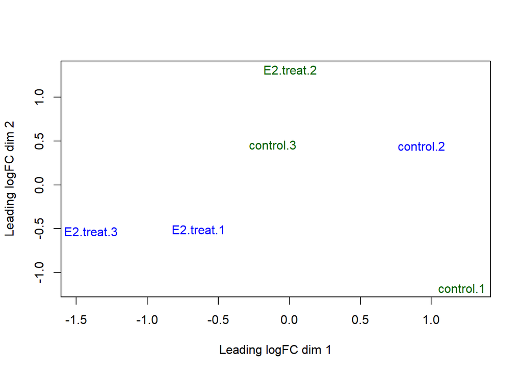

```r
heatmap_matrix <- t(scale(t(heatmap_matrix)))
if(min(heatmap_matrix) == 0){
    heatmap_col = colorRamp2(c( 0, max(heatmap_matrix)), c( "white", "red"))
  } else {
    heatmap_col = colorRamp2(c(min(heatmap_matrix), 0, max(heatmap_matrix)), c("blue", "white", "red"))
  }
current_heatmap <- Heatmap(as.matrix(heatmap_matrix),
                               show_row_dend = TRUE,
                               show_column_dend = TRUE,
                               col=heatmap_col,
                               show_column_names = TRUE,
                               show_row_names = FALSE,
                               show_heatmap_legend = TRUE
                               )

limma::plotMDS(heatmap_matrix,
               col = rep(c("darkgreen","blue"),10))
```

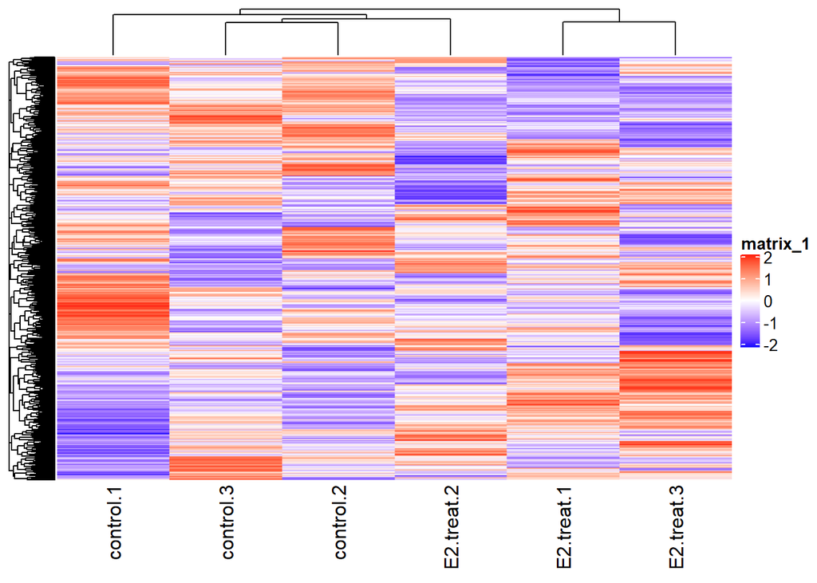

```r
current_heatmap
```

Refer to MDS plot, which treatment group the data comes from is important. In addition, data from different sequence within same treatment group does not cluster closely, so this may also be a factor.

```r
data_filtered <- read.csv('data_filtered.csv')
data_filtered <- data_filtered[,-1]
rownames(data_filtered) <- data_filtered$symbol
filtered_data_matrix <- as.matrix(data_filtered[,2:7])
samples <- data.frame(lapply(colnames(data_filtered)[2:7],
FUN=function(x){tail(unlist(strsplit(x, split = "\\.")),n=2)}))
colnames(samples) <- colnames(data_filtered)[2:7]
rownames(samples) <- c("treatment",'patients')
samples <- data.frame(t(samples))
```

Use Quasi likelihood from edgeR for 2 reasons. First, refer to lecture slides, edgeR are designed for processing of RNAseq data, and Limma guide direct users to use edgeR for differential expression. Second, my model has more than one factors. 0.05 is chosen for significance threshold, as convention.

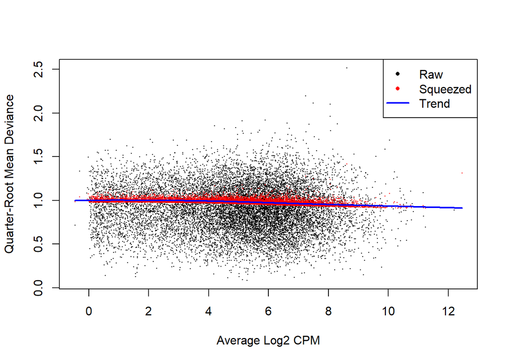

```r
model_treatment <- model.matrix(~samples$treatment)
model_treatment_pat <- model.matrix(~samples$treatmen+samples$patients)

d = DGEList(counts=filtered_data_matrix, group=samples$treatment)
d1 <- estimateDisp(d, model_treatment)
d <- estimateDisp(d, model_treatment_pat)
d <- calcNormFactors(d)

#fit1 <- exactTest(d1, model_treatment)
fit <- glmQLFit(d, model_treatment_pat)

plotQLDisp(fit)
```

```r
#qlf <- glmQLFTest(fit, coef=2:3)
qlf <- glmQLFTest(fit, coef='samples$treatmentreat')
knitr::kable(topTags(qlf),type = 'html')
```

|  | logFC | logCPM | F | PValue | FDR |
| --- | --- | --- | --- | --- | --- |
| DCHS1 | 1.6842638 | 5.719304 | 1637.5069 | 0 | 0 |
| MYOF | 1.8931825 | 4.052571 | 728.9670 | 0 | 0 |
| WNT16 | 3.3642576 | 3.054043 | 715.6545 | 0 | 0 |
| HSPB8 | 1.3950985 | 4.819755 | 674.9711 | 0 | 0 |
| NEFH | 1.3750600 | 4.217834 | 478.2935 | 0 | 0 |
| SYTL5 | 1.8948690 | 3.431776 | 432.4846 | 0 | 0 |
| PGR | 0.9706076 | 5.003349 | 391.8899 | 0 | 0 |
| GREB1 | 0.9164584 | 5.188410 | 385.8513 | 0 | 0 |
| SERPINB9 | 0.9553336 | 5.044922 | 362.7360 | 0 | 0 |
| TSKU | 0.7851126 | 5.355599 | 330.1227 | 0 | 0 |

| x |
| --- |
| BH |

| x |
| --- |
| samples$treatmentreat |

| x |
| --- |
| glm |

For correction method, refer to documentation of **topTags** about **method** parameter, choice of correction method decide whether FWDR or FDR will be returned. Since we prefer FDR, feasible option are ‘BH’,‘BY’ and ‘fdr’ where ‘fdr’ are equivalent to ‘BH’(refer to documentation of p.adjust). Refer to the paper The control of the false discovery rate in multiple testing under dependency, if the data show positive correlation or independency, BH procedure would be feasible. In addition, the default p-value adjustment for **topTags** function is also BH, so I chose BH as adjustment method here.

```r
qlf_output_hits <- topTags(qlf,adjust.method = 'BH',sort.by = "PValue", n = nrow(normalized_count))
#qlf_output_hits$table
knitr::kable(cor(data_filtered[2:7]),type = 'html', digits = 3)
```

[output not shown]

```r
length(which(qlf_output_hits$table$PValue < 0.05))
```

```
## [1] 3579
```

```r
length(which(qlf_output_hits$table$FDR < 0.05))
```

```
## [1] 1713
```

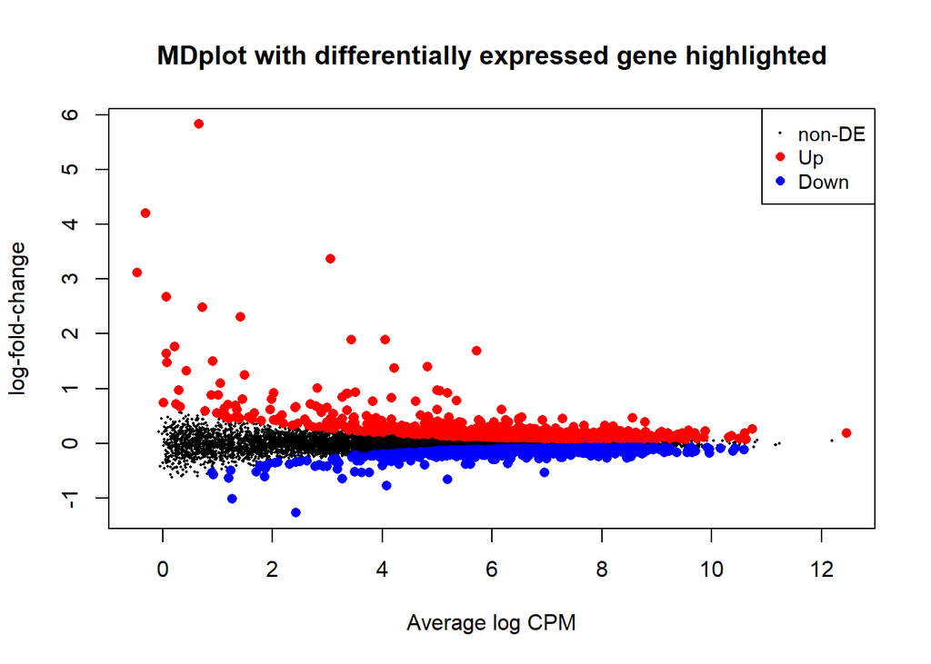

```r
plotMD(qlf, main = 'MDplot with differentially expressed gene highlighted')
```

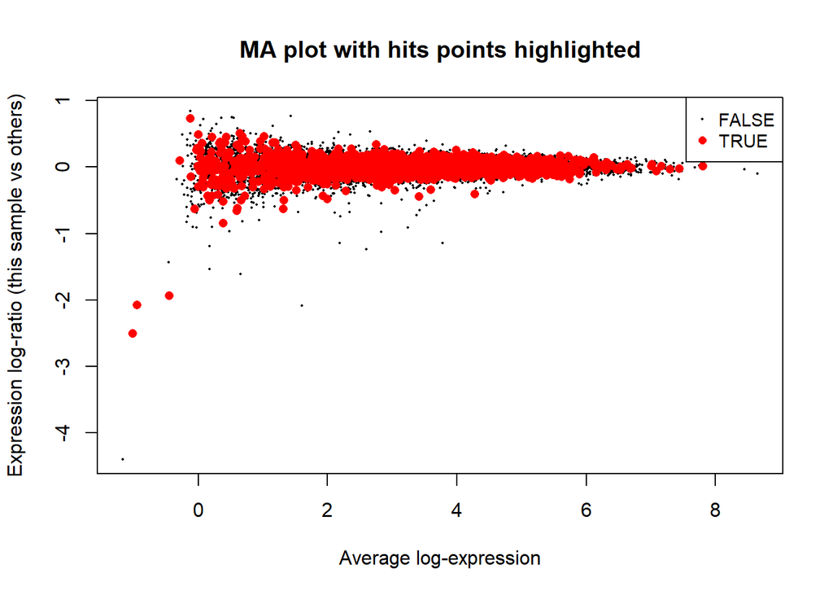

```r
highlight <- normalized_count[rownames(normalized_count) %in% rownames(qlf$table[qlf_output_hits$table$FDR < 0.05,]),]
limma::plotMA(log(normalized_count[,c(2,5)]),
              status = rownames(normalized_count) %in% rownames(qlf$table[qlf_output_hits$table$FDR < 0.05,]),
              main = 'MA plot with hits points highlighted')
```

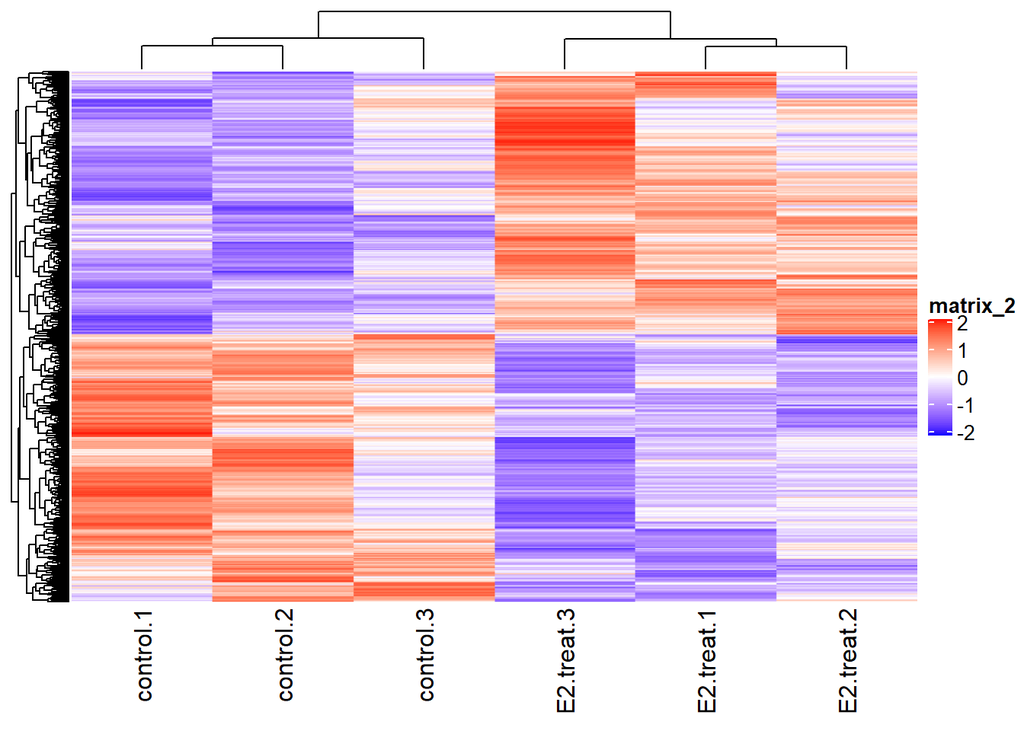

```r
top_hits <- rownames(qlf_output_hits$table)[qlf_output_hits$table$PValue < 0.05]
heatmap_matrix_tophits <- t(scale(t(heatmap_matrix[which(rownames(heatmap_matrix) %in% top_hits),])))
if(min(heatmap_matrix_tophits) == 0){
  heatmap_col = colorRamp2(c( 0, max(heatmap_matrix_tophits)),c( "white", "red"))
  } else {
    heatmap_col = colorRamp2(c(min(heatmap_matrix_tophits), 0,
                               max(heatmap_matrix_tophits)), c("blue", "white", "red"))
    }
current_heatmap <- Heatmap(as.matrix(heatmap_matrix_tophits),
                           cluster_rows = TRUE,
                           cluster_columns = TRUE,
                           show_row_dend = TRUE,
                           show_column_dend = TRUE,
                           col=heatmap_col,
                           show_column_names = TRUE,
                           show_row_names = FALSE,
                           show_heatmap_legend = TRUE,
                           )
current_heatmap
```

The heat map clustered.

# Thresholded over-representation analysis

```r
length(which(qlf_output_hits$table$FDR < 0.05 & qlf_output_hits$table$logFC.samples.treatmentreat > 0))
```

```
## [1] 0
```

```r
length(which(qlf_output_hits$table$FDR < 0.05 & qlf_output_hits$table$logFC.samples.treatmentreat < 0))
```

```
## [1] 0
```

```r
qlf_output_hits_withgn <- merge(normalized_count[,1],qlf_output_hits, by.x=1, by.y = 0)

qlf_output_hits_withgn[,"rank"] <- -log(qlf_output_hits_withgn$PValue,base =10) * sign(qlf_output_hits_withgn$logFC)
qlf_output_hits_withgn <- qlf_output_hits_withgn[order(qlf_output_hits_withgn$rank),]

upregulated_genes <- qlf_output_hits_withgn$x[ which(qlf_output_hits_withgn$FDR < 0.05 &
                                                           qlf_output_hits_withgn$logFC > 0)]
downregulated_genes <- qlf_output_hits_withgn$x[which(qlf_output_hits_withgn$FDR < 0.05 &
                                                            qlf_output_hits_withgn$logFC < 0)]

write.table(x=upregulated_genes, file=file.path("GSE_upregulated_genes.txt"),sep = "\t",
            row.names = FALSE,col.names = FALSE,quote = FALSE)
write.table(x=downregulated_genes, file=file.path("GSE_downregulated_genes.txt"),sep = "\t",
            row.names = FALSE,col.names = FALSE,quote = FALSE)

#write.table(x=data.frame(genename= qlf_output_hits_withgn$x,F_stat= qlf_output_hits_withgn$rank),)
```

For over-representatio analysi, I use g:GOST,the platform we used for homework2, with Bonferroni correction since Bonferroni is the most strict choice. The significance threshold is 0.05, as convention. As for choice of annotation, I use GO:BP, refer to the paper related to this dataset. KEGG does not return much result, like less than 10, and DAVID mentioned in the paper is not available from g:GOST.

For upregulated, top term returned is development process. For both down-regulated and combined, top term returned is SRP dependent Cotranslational protein targeting to membrane.

Top gene returned for this comparision for both down-regulated and combined is ESR1 while for up-regulated, it’s FBXO2.

```r
combined <- read.csv('combined.csv')
up <- read.csv('upregulated.csv')
down<- read.csv('downregulated.csv')

knitr::kable(combined[1:4], main = 'gGOST ORA result for combined',digits = 3)
```

| source | term_name | term_id | adjusted_p_value |
| --- | --- | --- | --- |
| GO:BP | SRP-dependent cotranslational protein targeting to membrane | GO:0006614 | 0.000 |
| GO:BP | viral transcription | GO:0019083 | 0.000 |
| GO:BP | cotranslational protein targeting to membrane | GO:0006613 | 0.000 |
| GO:BP | viral gene expression | GO:0019080 | 0.000 |
| GO:BP | viral process | GO:0016032 | 0.000 |
| GO:BP | symbiotic process | GO:0044403 | 0.000 |
| GO:BP | protein localization to endoplasmic reticulum | GO:0070972 | 0.000 |
| GO:BP | nuclear-transcribed mRNA catabolic process, nonsense-mediated decay | GO:0000184 | 0.000 |
| GO:BP | protein targeting to ER | GO:0045047 | 0.000 |
| GO:BP | establishment of protein localization to endoplasmic reticulum | GO:0072599 | 0.000 |
| GO:BP | interspecies interaction between organisms | GO:0044419 | 0.000 |
| GO:BP | mRNA catabolic process | GO:0006402 | 0.000 |
| GO:BP | nuclear-transcribed mRNA catabolic process | GO:0000956 | 0.000 |
| GO:BP | cellular component organization or biogenesis | GO:0071840 | 0.000 |
| GO:BP | cellular localization | GO:0051641 | 0.000 |
| GO:BP | RNA catabolic process | GO:0006401 | 0.000 |
| GO:BP | establishment of localization in cell | GO:0051649 | 0.000 |
| GO:BP | translational initiation | GO:0006413 | 0.000 |
| GO:BP | organelle organization | GO:0006996 | 0.000 |
| GO:BP | intracellular transport | GO:0046907 | 0.000 |
| GO:BP | protein localization to organelle | GO:0033365 | 0.000 |
| GO:BP | protein localization | GO:0008104 | 0.000 |
| GO:BP | cellular component organization | GO:0016043 | 0.000 |
| GO:BP | cellular protein localization | GO:0034613 | 0.000 |
| GO:BP | cellular macromolecule localization | GO:0070727 | 0.000 |
| GO:BP | nucleobase-containing compound catabolic process | GO:0034655 | 0.000 |
| GO:BP | macromolecule localization | GO:0033036 | 0.000 |
| GO:BP | establishment of protein localization to organelle | GO:0072594 | 0.000 |
| GO:BP | cellular catabolic process | GO:0044248 | 0.000 |
| GO:BP | cellular nitrogen compound catabolic process | GO:0044270 | 0.000 |

[output cut: 273 more lines]

```r
knitr::kable(up[1:4], main = 'gGOST ORA result for upregulated',digits = 3)
```

| source | term_name | term_id | adjusted_p_value |
| --- | --- | --- | --- |
| GO:BP | developmental process | GO:0032502 | 0.000 |
| GO:BP | cellular component organization or biogenesis | GO:0071840 | 0.000 |
| GO:BP | regulation of nucleobase-containing compound metabolic process | GO:0019219 | 0.000 |
| GO:BP | cellular component organization | GO:0016043 | 0.000 |
| GO:BP | regulation of RNA metabolic process | GO:0051252 | 0.000 |
| GO:BP | anatomical structure development | GO:0048856 | 0.000 |
| GO:BP | regulation of cellular metabolic process | GO:0031323 | 0.000 |
| GO:BP | positive regulation of RNA metabolic process | GO:0051254 | 0.000 |
| GO:BP | transcription by RNA polymerase II | GO:0006366 | 0.000 |
| GO:BP | positive regulation of nucleobase-containing compound metabolic process | GO:0045935 | 0.000 |
| GO:BP | multicellular organism development | GO:0007275 | 0.000 |
| GO:BP | regulation of transcription by RNA polymerase II | GO:0006357 | 0.000 |
| GO:BP | system development | GO:0048731 | 0.000 |
| GO:BP | regulation of nitrogen compound metabolic process | GO:0051171 | 0.000 |
| GO:BP | animal organ development | GO:0048513 | 0.000 |
| GO:BP | positive regulation of biological process | GO:0048518 | 0.000 |
| GO:BP | organelle organization | GO:0006996 | 0.000 |
| GO:BP | regulation of primary metabolic process | GO:0080090 | 0.000 |
| GO:BP | regulation of metabolic process | GO:0019222 | 0.000 |
| GO:BP | nucleic acid-templated transcription | GO:0097659 | 0.000 |
| GO:BP | RNA biosynthetic process | GO:0032774 | 0.000 |
| GO:BP | positive regulation of metabolic process | GO:0009893 | 0.000 |
| GO:BP | chromatin organization | GO:0006325 | 0.000 |
| GO:BP | positive regulation of cellular process | GO:0048522 | 0.000 |
| GO:BP | cytoskeleton organization | GO:0007010 | 0.000 |
| GO:BP | RNA metabolic process | GO:0016070 | 0.000 |
| GO:BP | positive regulation of cellular metabolic process | GO:0031325 | 0.000 |
| GO:BP | regulation of macromolecule metabolic process | GO:0060255 | 0.000 |
| GO:BP | positive regulation of nucleic acid-templated transcription | GO:1903508 | 0.000 |
| GO:BP | positive regulation of RNA biosynthetic process | GO:1902680 | 0.000 |

[output cut: 192 more lines]

```r
knitr::kable(down[1:4], main = 'gGOST ORA result for downregulated',digits = 3)
```

| source | term_name | term_id | adjusted_p_value |
| --- | --- | --- | --- |
| GO:BP | SRP-dependent cotranslational protein targeting to membrane | GO:0006614 | 0.000 |
| GO:BP | cotranslational protein targeting to membrane | GO:0006613 | 0.000 |
| GO:BP | protein targeting to ER | GO:0045047 | 0.000 |
| GO:BP | establishment of protein localization to endoplasmic reticulum | GO:0072599 | 0.000 |
| GO:BP | protein localization to endoplasmic reticulum | GO:0070972 | 0.000 |
| GO:BP | nuclear-transcribed mRNA catabolic process, nonsense-mediated decay | GO:0000184 | 0.000 |
| GO:BP | viral transcription | GO:0019083 | 0.000 |
| GO:BP | viral gene expression | GO:0019080 | 0.000 |
| GO:BP | viral process | GO:0016032 | 0.000 |
| GO:BP | symbiotic process | GO:0044403 | 0.000 |
| GO:BP | translational initiation | GO:0006413 | 0.000 |
| GO:BP | interspecies interaction between organisms | GO:0044419 | 0.000 |
| GO:BP | protein targeting to membrane | GO:0006612 | 0.000 |
| GO:BP | nuclear-transcribed mRNA catabolic process | GO:0000956 | 0.000 |
| GO:BP | mRNA catabolic process | GO:0006402 | 0.000 |
| GO:BP | RNA catabolic process | GO:0006401 | 0.000 |
| GO:BP | establishment of protein localization to membrane | GO:0090150 | 0.000 |
| GO:BP | nucleobase-containing compound catabolic process | GO:0034655 | 0.000 |
| GO:BP | protein targeting | GO:0006605 | 0.000 |
| GO:BP | cellular nitrogen compound catabolic process | GO:0044270 | 0.000 |
| GO:BP | heterocycle catabolic process | GO:0046700 | 0.000 |
| GO:BP | establishment of protein localization to organelle | GO:0072594 | 0.000 |
| GO:BP | aromatic compound catabolic process | GO:0019439 | 0.000 |
| GO:BP | organic cyclic compound catabolic process | GO:1901361 | 0.000 |
| GO:BP | protein localization to organelle | GO:0033365 | 0.000 |
| GO:BP | cellular catabolic process | GO:0044248 | 0.000 |
| GO:BP | establishment of protein localization | GO:0045184 | 0.000 |
| GO:BP | protein localization | GO:0008104 | 0.000 |
| GO:BP | protein transport | GO:0015031 | 0.000 |
| GO:BP | peptide transport | GO:0015833 | 0.000 |

[output cut: 147 more lines]

# Interpretation

The enrichment analysis result support conclusion in the original paper. Refer to gene summary provided by HGNC, ESR1 encodes an estrogen receptor. In addition, there are paper shows that term ‘GO:0006614 SRP-dependent cotranslational protein targeting to membrane’ is related to breast cancer. Since the orignal paper conclude that response of a certain drug for breast cancer is dependent on ER, the conclusion is supported.

# References

Benjamini, Yoav, and Daniel Yekutieli. 2001. “The Control of the False Discovery Rate in Multiple Testing Under Dependency.” *Annals of Statistics*, 1165–88.

Gu, Zuguang, Roland Eils, and Matthias Schlesner. 2016. “Complex Heatmaps Reveal Patterns and Correlations in Multidimensional Genomic Data.” *Bioinformatics* 32 (18): 2847–9.

Gu, Zuguang, Lei Gu, Roland Eils, Matthias Schlesner, and Benedikt Brors. 2014. “Circlize Implements and Enhances Circular Visualization in R.” *Bioinformatics* 30 (19): 2811–2.

McCarthy, Davis J, Yunshun Chen, and Gordon K Smyth. 2012. “Differential Expression Analysis of Multifactor Rna-Seq Experiments with Respect to Biological Variation.” *Nucleic Acids Research* 40 (10): 4288–97.

Petrossian, Karineh, Noriko Kanaya, Chiao Lo, Pei-Yin Hsu, Duc Nguyen, Lixin Yang, Lu Yang, et al. 2018. “ER$\alpha$-Mediated Cell Cycle Progression Is an Important Requisite for Cdk4/6 Inhibitor Response in Hr+ Breast Cancer.” *Oncotarget* 9 (45): 27736.

Robinson, Mark D, Davis J McCarthy, and Gordon K Smyth. 2010. “EdgeR: A Bioconductor Package for Differential Expression Analysis of Digital Gene Expression Data.” *Bioinformatics* 26 (1): 139–40.

Zhang, Shuqin. 2018. “Comparisons of Gene Coexpression Network Modules in Breast Cancer and Ovarian Cancer.” *BMC Systems Biology* 12 (1): 8.